# Validation of Grimes’ GRIM-U code

Ian Hussey

08 January, 2026

# Dependencies

```r
library(tidyverse)
library(waldo)
```

# Grimes’ original code (v2)

```r
simrank <- function(n1, n2, U_target, max_iter = 100000) {
  total_ranks <- 1:(n1 + n2)
  R1_target <- U_target + n1 * (n1 + 1) / 2

  for (i in 1:max_iter) {
    group1_ranks <- sort(sample(total_ranks, n1, replace = FALSE))
    if (sum(group1_ranks) == R1_target) {
      group2_ranks <- setdiff(total_ranks, group1_ranks)
      return(list(
        group1_ranks = group1_ranks,
        group2_ranks = group2_ranks,
        U = U_target
      ))
    }
  }

  # Return NA instead of stopping with an error
  return(NA)
}


#Here enter in your n1 and n2
n1 <- 18
n2 <- 60

#Expected stats (Ties and no ties)
uexp <- (n1*n2)/2
seu <- sqrt(n1*n2*(n1+n2+1)/12)
seu_tie <- sqrt(n1*n2*(n1+n2+1)/12 - n1*n2*(7)/(12*(n1 + n2)*(n1 + n2 - 1)) )

#range of p-values of interest
pvals <- seq(0.01, 0.10, by = 0.005)
zscores <- qnorm(1 - pvals/2)

#conversion (no ties)
upred <- seu*zscores + uexp  #has higher max value
upredtie <- seu_tie*zscores + uexp #has lower min value
vals <- seq(floor(upredtie[length(upredtie)]),ceiling(upred[1]) , by = 0.5)
exactval <- rep(NA_real_, length(vals))
spssval <- rep(NA_real_, length(vals))




#Let it run
i <- 1
while (i <= length(vals)) {
  k <- vals[i]
  j <- simrank(n1, n2, U_target = round(k))

  # Skip iteration if simulation failed
  if (is.na(j[1])) {
    exactval[i] <- NA
    spssval[i] <- NA
    i <- i + 1
    next
  }

  # If k is an integer
  if (round(k) == k) {
    m1 <- wilcox.test(j$group1_ranks, j$group2_ranks)
    m2 <- wilcox.test(j$group1_ranks, j$group2_ranks, correct = FALSE, exact = FALSE)
  } else {
    # Adjust one value to simulate a fractional rank
    w <- which(diff(j$group2_ranks) == 2)[1]
    if (!is.na(w)) {
      mv <- j$group2_ranks[w]
      j$group2_ranks[w] <- mv + 0.5

      w2 <- which(j$group1_ranks == mv + 1)
      if (length(w2) > 0) {
        j$group1_ranks[w2] <- mv + 0.5
      }
    }

    m1 <- wilcox.test(j$group1_ranks, j$group2_ranks)
    m2 <- wilcox.test(j$group1_ranks, j$group2_ranks, correct = FALSE, exact = FALSE)
  }

  exactval[i] <- m1$p.value
  spssval[i] <- m2$p.value

  i <- i + 1
}

n1v <- rep(n1,i-1)
n2v <- rep(n2,i-1)

df <- data.frame("U_Values" = vals, "P_Exact" = exactval, "Approx P" = spssval)
df$Diff <- abs(df$Approx.P - df$P_Exact)
df$n1 <- n1v
df$n2 <- n2v
```

Ian’s minor addition to allow comparisons:

```r
df <- df |>
  rename(p_approx = Approx.P,
         p_exact = P_Exact) |>
  as_tibble()
```

# Fixed issue re rounding k

simrank() requires an integer input for U. To simulate a half-integer target (e.g., 70.5), the code must simulate the integer above it (e.g., 71) and then force a tie. This tie mathematically subtracts 0.5 from the score, hitting the target ($71 - 0.5 = 70.5$).

However, the original code used `round()`, which follows “Banker’s Rounding” (rounding to the nearest even number). eg

```r
round(0.5)
```

```
## [1] 0
```

```r
round(1.5)
```

```
## [1] 2
```

```r
round(2.5)
```

```
## [1] 2
```

```r
round(3.5)
```

```
## [1] 4
```

```r
round(4.5)
```

```
## [1] 4
```

```r
round(5.5)
```

```
## [1] 6
```

This creates a bug in 50% of cases.

- Failure Case: For a target of 70.5, round(70.5) rounds down to 70. The tie logic then calculates $70 - 0.5 = 69.5$, which is incorrect.
- Success Case: For a target of 71.5, round(71.5) rounds up to 72. The tie logic calculates $72 - 0.5 = 71.5$, which works.

The fix is to use `ceiling()` instead of `round()`. `ceiling()` always rounds up to the next integer, ensuring we always start with the higher value needed for the subtraction logic.

So `j <- simrank(n1, n2, U_target = round(k))` becomes `U0 <- if (k %% 1 != 0) ceiling(k) else k; j <- simrank(n1, n2, U_target = U0)`

An alternative would be Lukas Jung’s excellent {roundwork} package for `round_up()` to produce the expected behavior, but that’s another dependency.

```r
simrank <- function(n1, n2, U_target, max_iter = 100000) {
  total_ranks <- 1:(n1 + n2)
  R1_target <- U_target + n1 * (n1 + 1) / 2

  for (i in 1:max_iter) {
    group1_ranks <- sort(sample(total_ranks, n1, replace = FALSE))
    if (sum(group1_ranks) == R1_target) {
      group2_ranks <- setdiff(total_ranks, group1_ranks)
      return(list(
        group1_ranks = group1_ranks,
        group2_ranks = group2_ranks,
        U = U_target
      ))
    }
  }

  # Return NA instead of stopping with an error
  return(NA)
}


#Here enter in your n1 and n2
n1 <- 18
n2 <- 60

#Expected stats (Ties and no ties)
uexp <- (n1*n2)/2
seu <- sqrt(n1*n2*(n1+n2+1)/12)
seu_tie <- sqrt(n1*n2*(n1+n2+1)/12 - n1*n2*(7)/(12*(n1 + n2)*(n1 + n2 - 1)) )

#range of p-values of interest
pvals <- seq(0.01, 0.10, by = 0.005)
zscores <- qnorm(1 - pvals/2)

#conversion (no ties)
upred <- seu*zscores + uexp  #has higher max value
upredtie <- seu_tie*zscores + uexp #has lower min value
vals <- seq(floor(upredtie[length(upredtie)]),ceiling(upred[1]) , by = 0.5)
exactval <- rep(NA_real_, length(vals))
spssval <- rep(NA_real_, length(vals))




#Let it run
i <- 1
while (i <= length(vals)) {
  k <- vals[i]

  # changed here:
  # original
  # j <- simrank(n1, n2, U_target = round(k))
  # updated
  U0 <- if (k %% 1 != 0) ceiling(k) else k
  j <- simrank(n1, n2, U_target = U0)

  # Skip iteration if simulation failed
  if (is.na(j[1])) {
    exactval[i] <- NA
    spssval[i] <- NA
    i <- i + 1
    next
  }

  # If k is an integer
  if (round(k) == k) {
    m1 <- wilcox.test(j$group1_ranks, j$group2_ranks)
    m2 <- wilcox.test(j$group1_ranks, j$group2_ranks, correct = FALSE, exact = FALSE)
  } else {
    # Adjust one value to simulate a fractional rank
    w <- which(diff(j$group2_ranks) == 2)[1]
    if (!is.na(w)) {
      mv <- j$group2_ranks[w]
      j$group2_ranks[w] <- mv + 0.5

      w2 <- which(j$group1_ranks == mv + 1)
      if (length(w2) > 0) {
        j$group1_ranks[w2] <- mv + 0.5
      }
    }

    m1 <- wilcox.test(j$group1_ranks, j$group2_ranks)
    m2 <- wilcox.test(j$group1_ranks, j$group2_ranks, correct = FALSE, exact = FALSE)
  }

  exactval[i] <- m1$p.value
  spssval[i] <- m2$p.value

  i <- i + 1
}

n1v <- rep(n1,i-1)
n2v <- rep(n2,i-1)

df_fixed <- data.frame("U_Values" = vals, "P_Exact" = exactval, "Approx P" = spssval)
df_fixed$Diff <- abs(df_fixed$Approx.P - df_fixed$P_Exact)
df_fixed$n1 <- n1v
df_fixed$n2 <- n2v
```

Ian’s minor addition to allow comparisons:

```r
df_fixed <- df_fixed |>
  rename(p_approx = Approx.P,
         p_exact = P_Exact) |>
  as_tibble()
```

## Comparing original and fixed

```r
waldo::compare(df, df_fixed, max_diffs = Inf)
```

```
## old vs new
##                 p_exact    p_approx         Diff
##   old[1, ]   0.10295853 0.101712705 0.0012458249
## - old[2, ]   0.10421427 0.102956353 0.0012579166
## + new[2, ]   0.10171054 0.100476762 0.0012337799
##   old[3, ]   0.10047891 0.099257078 0.0012218346
##   old[4, ]   0.09925494 0.098045004 0.0012099362
##   old[5, ]   0.09804713 0.096848991 0.0011981377
## - old[6, ]   0.09925494 0.098045004 0.0012099362
## + new[6, ]   0.09684688 0.095660494 0.0011863863
##   old[7, ]   0.09566259 0.094487856 0.0011747352
##   old[8, ]   0.09448577 0.093322640 0.0011631313
##   old[9, ]   0.09332471 0.092173083 0.0011516278
## - old[10, ]  0.09448577 0.093322640 0.0011631313
## + new[10, ]  0.09217103 0.091030854 0.0011401717
##   old[11, ]  0.09103290 0.089904082 0.0011288162
##   old[12, ]  0.08990205 0.088784543 0.0011175081
##   old[13, ]  0.08878656 0.087680260 0.0011063008
## - old[14, ]  0.08990205 0.088784543 0.0011175081
## + new[14, ]  0.08767826 0.086583115 0.0010951410
##   old[15, ]  0.08658511 0.085501024 0.0010840820
##   old[16, ]  0.08549905 0.084425976 0.0010730706
##   old[17, ]  0.08442794 0.083365780 0.0010621601
## - old[18, ]  0.08549905 0.084425976 0.0010730706
## + new[18, ]  0.08336383 0.082312532 0.0010512971
##   old[19, ]  0.08231447 0.081273934 0.0010405351
##   old[20, ]  0.08127201 0.080242189 0.0010298206
##   old[21, ]  0.08024410 0.079224893 0.0010192070
## - old[22, ]  0.08127201 0.080242189 0.0010298206
## + new[22, ]  0.07922300 0.078214355 0.0010086409
##   old[23, ]  0.07821624 0.077218063 0.0009981757
##   old[24, ]  0.07721619 0.076228434 0.0009877579
##   old[25, ]  0.07623029 0.075252851 0.0009774409
## - old[26, ]  0.07721619 0.076228434 0.0009877579
## + new[26, ]  0.07525101 0.074283836 0.0009671712
##   old[27, ]  0.07428567 0.073328665 0.0009570022
##   old[28, ]  0.07332685 0.072379966 0.0009468804
##   old[29, ]  0.07238177 0.071444912 0.0009368591
## - old[30, ]  0.07332685 0.072379966 0.0009468804
## + new[30, ]  0.07144312 0.070516236 0.0009268849
```

[output cut: 637 more lines]

```
## [147] 0.0002082 | 0.0002082 [147]
## [148] 0.0002051 | 0.0002051 [148]
## [149] 0.0002021 | 0.0002021 [149]
## [150] 0.0002051 - 0.0001991 [150]
## [151] 0.0001962 | 0.0001962 [151]
## [152] 0.0001932 | 0.0001932 [152]
## [153] 0.0001904 | 0.0001904 [153]
## [154] 0.0001932 - 0.0001875 [154]
## [155] 0.0001847 | 0.0001847 [155]
## [156] 0.0001819 | 0.0001819 [156]
## [157] 0.0001792 | 0.0001792 [157]
## [158] 0.0001819 - 0.0001765 [158]
## [159] 0.0001738 | 0.0001738 [159]
## [160] 0.0001712 | 0.0001712 [160]
## [161] 0.0001686 | 0.0001686 [161]
```

- this changes p_exact and p_exact values by up to c. .003, and affects a large proportion of cases.

# Refactored to functions+purrr::map

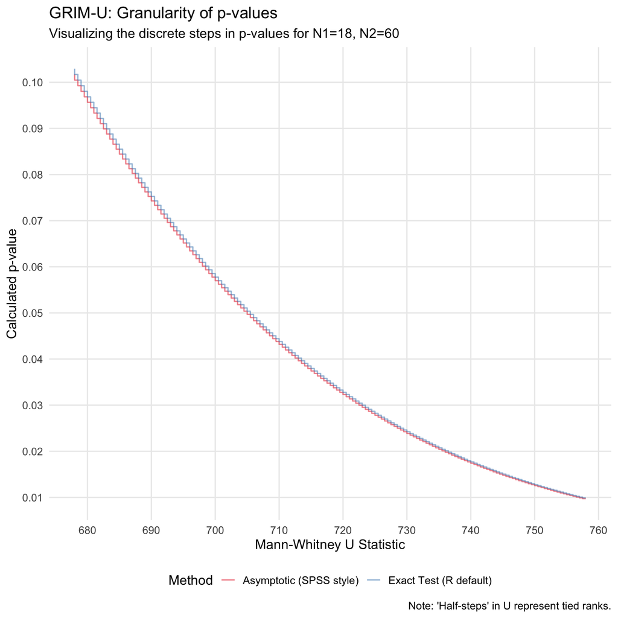

```r
# --- original ---
simrank <- function(n1, n2, U_target, max_iter = 100000) {
  total_ranks <- 1:(n1 + n2)
  R1_target <- U_target + n1 * (n1 + 1) / 2

  for (i in 1:max_iter) {
    group1_ranks <- sort(sample(total_ranks, n1, replace = FALSE))
    if (sum(group1_ranks) == R1_target) {
      group2_ranks <- setdiff(total_ranks, group1_ranks)
      return(list(
        group1_ranks = group1_ranks,
        group2_ranks = group2_ranks,
        U = U_target
      ))
    }
  }

  # Return NA instead of stopping with an error
  return(NA)
}

# --- simulation helper function ---
run_simulation_step <- function(k, n1, n2) {

  # --- LOGIC FIX: Use ceiling() for correct tie handling ---
  # If k is 70.5, we need to generate U=71 (ceiling) and subtract 0.5.
  # The original code used round(), which failed for even integers (e.g. 70.5 -> 70).
  U0 <- if (k %% 1 != 0) ceiling(k) else k

  # Run simulation (requires your simrank function to be loaded)
  j <- simrank(n1, n2, U_target = U0)

  # --- FAILURE HANDLING ---
  if (is.na(j[1])) {
    return(tibble(p_exact = NA_real_, p_approx = NA_real_))
  }

  # --- TIE INJECTION LOGIC ---
  if (k %% 1 == 0) {
    # Integer K: Standard Test
    m1 <- wilcox.test(j$group1_ranks, j$group2_ranks)
    m2 <- wilcox.test(j$group1_ranks, j$group2_ranks, correct = FALSE, exact = FALSE)
  } else {
    # Adjust one value to simulate a fractional rank
    w <- which(diff(j$group2_ranks) == 2)[1]
    if (!is.na(w)) {
      mv <- j$group2_ranks[w]
      j$group2_ranks[w] <- mv + 0.5

      w2 <- which(j$group1_ranks == mv + 1)
      if (length(w2) > 0) {
        j$group1_ranks[w2] <- mv + 0.5
      }
    }

    m1 <- wilcox.test(j$group1_ranks, j$group2_ranks)
    m2 <- wilcox.test(j$group1_ranks, j$group2_ranks, correct = FALSE, exact = FALSE)
  }

  return(tibble(p_exact = m1$p.value,
                p_approx = m2$p.value))
}


# --- 3. Main Analysis Function ---
grimu_analyze <- function(n1, n2, p_min = 0.01, p_max = 0.10, step = 0.005) {

  # --- Setup Calculation ---
  # 1. Expected stats (Ties and no ties)
  uexp <- (n1 * n2) / 2
  seu  <- sqrt(n1 * n2 * (n1 + n2 + 1) / 12)
  # Standard Error with tie correction factor
  seu_tie <- sqrt(n1 * n2 * (n1 + n2 + 1) / 12 -
                    n1 * n2 * (7) / (12 * (n1 + n2) * (n1 + n2 - 1)))

  # 2. Range of p-values to U-values conversion
  # Determine Z-scores for the p-value bounds
  pvals_range <- c(p_min, p_max)
  zscores <- qnorm(1 - pvals_range / 2) # Note: z[1] is high Z (low p), z[2] is low Z (high p)

  # 3. Calculate U Bounds
  # Upper U (corresponds to lowest p-value / highest Z)
  u_upper <- seu * zscores[1] + uexp
  # Lower U (corresponds to highest p-value / lowest Z, using tie SE)
  u_lower <- seu_tie * zscores[2] + uexp

  # 4. Generate Sequence of U-values to Test
  vals <- seq(floor(u_lower), ceiling(u_upper), by = 0.5)

  result_df <- tibble(U_Values = vals) %>%
    mutate(
      sim_results = map(U_Values, run_simulation_step, n1 = n1, n2 = n2)
    ) %>%
    unnest(sim_results) %>%
    mutate(
      Diff = abs(p_approx - p_exact),
      n1 = n1,
      n2 = n2
    )

  return(result_df)
}

plot_grimu_steps <- function(df_results) {

  # 1. Reshape data to long format for easy plotting of both methods
  plot_data <- df_results %>%
    pivot_longer(
      cols = c(p_exact, p_approx),
      names_to = "Method",
      values_to = "p_value"
    ) %>%
    mutate(
      Method = recode(Method,
                      "p_exact" = "Exact Test (R default)",
                      "p_approx" = "Asymptotic (SPSS style)")
    )

  # 2. Create Plot
  ggplot(plot_data, aes(x = U_Values, y = p_value, color = Method, shape = Method)) +
    # # Add points to show the discrete calculated values
    # geom_point(size = 1, alpha = 0.8) +
    # Add step lines to emphasize the "staircase" nature of the p-values
    geom_step(direction = "vh", linetype = "solid", alpha = 0.5) +
    # Scales and Labels
    scale_y_continuous(n.breaks = 10) +
    scale_x_continuous(n.breaks = 10) +
    scale_color_brewer(palette = "Set1") +
    labs(
      title = "GRIM-U: Granularity of p-values",
      subtitle = paste0("Visualizing the discrete steps in p-values for N1=",
                        unique(df_results$n1), ", N2=", unique(df_results$n2)),
      x = "Mann-Whitney U Statistic",
      y = "Calculated p-value",
      caption = "Note: 'Half-steps' in U represent tied ranks."
    ) +
    theme_minimal(base_size = 14) +
    theme(
      legend.position = "bottom",
      panel.grid.minor = element_blank() # Remove minor grid to see steps clearly
    )
}

# run the analysis
df_refactored <- grimu_analyze(n1 = 18, n2 = 60, p_min = 0.01, p_max = 0.10)

# plot
plot_grimu_steps(df_refactored)
```

## Comparing original and fixed

```r
waldo::compare(df_fixed, df_refactored, max_diffs = Inf)
```

```
## ✔ No differences
```

- the refactored and fixed versions produce identical results, at least for these values of the inputs.